# Horse Racing Data Analysis Project - ML1 HS24

sindhu.chinnamsetti@stud.hslu.ch, ronald.schwalb@stud.hslu.ch, eniko.simo@stud.hslu.ch

Jan 5, 2025

# 1) Data Cleaning

## WIP

```r
# Import the Data from CSV Files
df1 <- read.csv("Lingfield_AW_2014_2024_flat.csv")
df2 <- read.csv("Lingfield_AW_2014_2024_jumps.csv")
df3 <- read.csv("Lingfield_turf_2014_2024_flat.csv")
df4 <- read.csv("Lingfield_turf_2014_2024_jumps.csv")

df.horse <- rbind(df1, df2, df3, df4)

str(df.horse)
```

```
## 'data.frame':    53368 obs. of  39 variables:
##  $ date       : chr  "2014-01-04" "2014-01-04" "2014-01-04" "2014-01-04" ...
##  $ region     : chr  "GB" "GB" "GB" "GB" ...
##  $ course     : chr  "Lingfield (AW)" "Lingfield (AW)" "Lingfield (AW)" "Lingfield (AW)" ...
##  $ off        : chr  "11:50" "11:50" "11:50" "11:50" ...
##  $ race_name  : chr  "Coral Mobile Just Three Clicks To Bet Classified Claiming Stakes" "Coral Mobile Just Three Clicks To Bet Classified Claiming Stakes" "Coral Mobile Just Three Clicks To Bet Classified Claiming Stakes" "Coral Mobile Just Three Clicks To Bet Classified Claiming Stakes" ...
##  $ type       : chr  "Flat" "Flat" "Flat" "Flat" ...
##  $ class      : chr  "Class 6" "Class 6" "Class 6" "Class 6" ...
##  $ pattern    : chr  "" "" "" "" ...
##  $ rating_band: chr  "0-70" "0-70" "0-70" "0-70" ...
##  $ age_band   : chr  "4yo+" "4yo+" "4yo+" "4yo+" ...
##  $ sex_rest   : chr  "" "" "" "" ...
##  $ dist       : chr  "1m2f" "1m2f" "1m2f" "1m2f" ...
##  $ dist_f     : chr  "10f" "10f" "10f" "10f" ...
##  $ dist_m     : int  2012 2012 2012 2012 2012 2012 2012 2012 2012 2012 ...
```

[output cut: 25 more lines]

```r
head(df.horse)
```

|  | date | region | course | off | race_name | type | class | pattern | rating_band | age_band | sex_rest | dist | dist_f | dist_m | going | ran | num | pos | draw | ovr_btn | btn | horse | age | sex | lbs | hg | time | secs | dec | … |
| --- | --- | --- | --- | --- | --- | --- | --- | --- | --- | --- | --- | --- | --- | --- | --- | --- | --- | --- | --- | --- | --- | --- | --- | --- | --- | --- | --- | --- | --- | --- |
| 1 | 2014-01-04 | GB | Lingfield (AW) | 11:50 | Coral Mobile Just Three Clicks To Bet Classified Claiming Stakes | Flat | Class 6 |  | 0-70 | 4yo+ |  | 1m2f | 10f | 2012 | Standard | 11 | 3 | 1 | 7 | 0 | 0 | Ocean Applause (GB) | 4 | G | 113 | t | 2:4.96 | 124.96 | 4.0 | … |
| 2 | 2014-01-04 | GB | Lingfield (AW) | 11:50 | Coral Mobile Just Three Clicks To Bet Classified Claiming Stakes | Flat | Class 6 |  | 0-70 | 4yo+ |  | 1m2f | 10f | 2012 | Standard | 11 | 9 | 2 | 12 | .75 | .75 | Copperwood (GB) | 9 | G | 115 |  | 2:5.11 | 125.11 | 6.0 | … |
| 3 | 2014-01-04 | GB | Lingfield (AW) | 11:50 | Coral Mobile Just Three Clicks To Bet Classified Claiming Stakes | Flat | Class 6 |  | 0-70 | 4yo+ |  | 1m2f | 10f | 2012 | Standard | 11 | 5 | 3 | 4 | 2.25 | 1.5 | Paddys Saltantes (IRE) | 4 | G | 118 | b | 2:5.41 | 125.41 | 9.0 | … |
| 4 | 2014-01-04 | GB | Lingfield (AW) | 11:50 | Coral Mobile Just Three Clicks To Bet Classified Claiming Stakes | Flat | Class 6 |  | 0-70 | 4yo+ |  | 1m2f | 10f | 2012 | Standard | 11 | 4 | 4 | 3 | 3.5 | 1.25 | Exclusive Waters (IRE) | 4 | G | 118 | b | 2:5.66 | 125.66 | 4.5 | … |
| 5 | 2014-01-04 | GB | Lingfield (AW) | 11:50 | Coral Mobile Just Three Clicks To Bet Classified Claiming Stakes | Flat | Class 6 |  | 0-70 | 4yo+ |  | 1m2f | 10f | 2012 | Standard | 11 | 8 | 5 | 5 | 6 | 2.5 | Honey Of A Kitten (USA) | 6 | G | 116 | b | 2:6.16 | 126.16 | 8.0 | … |
| 6 | 2014-01-04 | GB | Lingfield (AW) | 11:50 | Coral Mobile Just Three Clicks To Bet Classified Claiming Stakes | Flat | Class 6 |  | 0-70 | 4yo+ |  | 1m2f | 10f | 2012 | Standard | 11 | 1 | 6 | 11 | 8.5 | 2.5 | Tempuran (GB) | 5 | G | 128 | p | 2:6.66 | 126.66 | 21.0 | … |

- gotta diminish dataset size to:
- max 10^5 = 100,000 rows
- 10-20 predictors

Keep the following columns based on domain knowledge and careful inspection of the dataset:

```r
df.horse <- subset(df.horse, select=c(date, race_name,type, class, dist_m, going, ran, pos, draw, horse, age, sex, lbs, hg, secs, jockey, trainer, prize))

str(df.horse)
```

```
## 'data.frame':    53368 obs. of  18 variables:
##  $ date     : chr  "2014-01-04" "2014-01-04" "2014-01-04" "2014-01-04" ...
##  $ race_name: chr  "Coral Mobile Just Three Clicks To Bet Classified Claiming Stakes" "Coral Mobile Just Three Clicks To Bet Classified Claiming Stakes" "Coral Mobile Just Three Clicks To Bet Classified Claiming Stakes" "Coral Mobile Just Three Clicks To Bet Classified Claiming Stakes" ...
##  $ type     : chr  "Flat" "Flat" "Flat" "Flat" ...
##  $ class    : chr  "Class 6" "Class 6" "Class 6" "Class 6" ...
##  $ dist_m   : int  2012 2012 2012 2012 2012 2012 2012 2012 2012 2012 ...
##  $ going    : chr  "Standard" "Standard" "Standard" "Standard" ...
##  $ ran      : int  11 11 11 11 11 11 11 11 11 11 ...
##  $ pos      : chr  "1" "2" "3" "4" ...
##  $ draw     : int  7 12 4 3 5 11 6 1 2 9 ...
##  $ horse    : chr  "Ocean Applause (GB)" "Copperwood (GB)" "Paddys Saltantes (IRE)" "Exclusive Waters (IRE)" ...
##  $ age      : int  4 9 4 4 6 5 6 5 7 8 ...
##  $ sex      : chr  "G" "G" "G" "G" ...
##  $ lbs      : int  113 115 118 118 116 128 115 116 118 115 ...
##  $ hg       : chr  "t" "" "b" "b" ...
##  $ secs     : chr  "124.96" "125.11" "125.41" "125.66" ...
##  $ jockey   : chr  "Joe Doyle" "Jimmy Quinn" "Luke Morris" "Andrea Atzeni" ...
##  $ trainer  : chr  "John Ryan" "Lee Carter" "J S Moore" "Gary Moore" ...
##  $ prize    : num  2045 604 302 NA NA ...
```

```r
head(df.horse)
```

|  | date | race_name | type | class | dist_m | going | ran | pos | draw | horse | age | sex | lbs | hg | secs | jockey | trainer | prize |
| --- | --- | --- | --- | --- | --- | --- | --- | --- | --- | --- | --- | --- | --- | --- | --- | --- | --- | --- |
| 1 | 2014-01-04 | Coral Mobile Just Three Clicks To Bet Classified Claiming Stakes | Flat | Class 6 | 2012 | Standard | 11 | 1 | 7 | Ocean Applause (GB) | 4 | G | 113 | t | 124.96 | Joe Doyle | John Ryan | 2045.1 |
| 2 | 2014-01-04 | Coral Mobile Just Three Clicks To Bet Classified Claiming Stakes | Flat | Class 6 | 2012 | Standard | 11 | 2 | 12 | Copperwood (GB) | 9 | G | 115 |  | 125.11 | Jimmy Quinn | Lee Carter | 603.9 |
| 3 | 2014-01-04 | Coral Mobile Just Three Clicks To Bet Classified Claiming Stakes | Flat | Class 6 | 2012 | Standard | 11 | 3 | 4 | Paddys Saltantes (IRE) | 4 | G | 118 | b | 125.41 | Luke Morris | J S Moore | 302.1 |
| 4 | 2014-01-04 | Coral Mobile Just Three Clicks To Bet Classified Claiming Stakes | Flat | Class 6 | 2012 | Standard | 11 | 4 | 3 | Exclusive Waters (IRE) | 4 | G | 118 | b | 125.66 | Andrea Atzeni | Gary Moore | NA |
| 5 | 2014-01-04 | Coral Mobile Just Three Clicks To Bet Classified Claiming Stakes | Flat | Class 6 | 2012 | Standard | 11 | 5 | 5 | Honey Of A Kitten (USA) | 6 | G | 116 | b | 126.16 | Nicky Mackay | David Evans | NA |
| 6 | 2014-01-04 | Coral Mobile Just Three Clicks To Bet Classified Claiming Stakes | Flat | Class 6 | 2012 | Standard | 11 | 6 | 11 | Tempuran (GB) | 5 | G | 128 | p | 126.66 | Stephen Craine | David Bridgwater | NA |

Create a new column ‘won’, assigning 1 if ‘pos’ is 1, otherwise 0

```r
df.horse$won <- ifelse(df.horse$pos == 1, 1, 0)
# Check the first few rows to ensure the new column has been added
head(df.horse[c("pos","won")],50)
```

|  | pos | won |
| --- | --- | --- |
| 1 | 1 | 1 |
| 2 | 2 | 0 |
| 3 | 3 | 0 |
| 4 | 4 | 0 |
| 5 | 5 | 0 |
| 6 | 6 | 0 |
| 7 | 7 | 0 |
| 8 | 8 | 0 |
| 9 | 9 | 0 |
| 10 | 10 | 0 |

[output cut: 40 more lines]

```r
# => looks good
```

```r
df.horse$place <- ifelse(df.horse$pos == c(1,2,3), 1, 0)
# Check the first few rows to ensure the new column has been added
head(df.horse[c("pos","place")],50)
```

|  | pos | place |
| --- | --- | --- |
| 1 | 1 | 1 |
| 2 | 2 | 1 |
| 3 | 3 | 1 |
| 4 | 4 | 0 |
| 5 | 5 | 0 |
| 6 | 6 | 0 |
| 7 | 7 | 0 |
| 8 | 8 | 0 |
| 9 | 9 | 0 |
| 10 | 10 | 0 |

[output cut: 40 more lines]

```r
# => looks good ???
```

Check for missing values. NAs and empty strings

```r
colSums(is.na(df.horse) | df.horse == "")
```

```
##      date race_name      type     class    dist_m     going       ran       pos
##         0         0         0         0         0         0         0         0
##      draw     horse       age       sex       lbs        hg      secs    jockey
##      3950         0         0         0         0     34045         0         0
##   trainer     prize       won     place
##         0     22402         0         0
```

```r
# let's drop hg and prize because most of them are missing
# but let's keep draw because AFAIK it might influence outcome
# keep it in mind that it only exists for Flat course type

df.horse <- subset(df.horse, select=-c(hg,prize))
```

Check datatypes.

```r
str(df.horse)
```

```
## 'data.frame':    53368 obs. of  18 variables:
##  $ date     : chr  "2014-01-04" "2014-01-04" "2014-01-04" "2014-01-04" ...
##  $ race_name: chr  "Coral Mobile Just Three Clicks To Bet Classified Claiming Stakes" "Coral Mobile Just Three Clicks To Bet Classified Claiming Stakes" "Coral Mobile Just Three Clicks To Bet Classified Claiming Stakes" "Coral Mobile Just Three Clicks To Bet Classified Claiming Stakes" ...
##  $ type     : chr  "Flat" "Flat" "Flat" "Flat" ...
##  $ class    : chr  "Class 6" "Class 6" "Class 6" "Class 6" ...
##  $ dist_m   : int  2012 2012 2012 2012 2012 2012 2012 2012 2012 2012 ...
##  $ going    : chr  "Standard" "Standard" "Standard" "Standard" ...
##  $ ran      : int  11 11 11 11 11 11 11 11 11 11 ...
##  $ pos      : chr  "1" "2" "3" "4" ...
##  $ draw     : int  7 12 4 3 5 11 6 1 2 9 ...
##  $ horse    : chr  "Ocean Applause (GB)" "Copperwood (GB)" "Paddys Saltantes (IRE)" "Exclusive Waters (IRE)" ...
##  $ age      : int  4 9 4 4 6 5 6 5 7 8 ...
##  $ sex      : chr  "G" "G" "G" "G" ...
##  $ lbs      : int  113 115 118 118 116 128 115 116 118 115 ...
##  $ secs     : chr  "124.96" "125.11" "125.41" "125.66" ...
##  $ jockey   : chr  "Joe Doyle" "Jimmy Quinn" "Luke Morris" "Andrea Atzeni" ...
##  $ trainer  : chr  "John Ryan" "Lee Carter" "J S Moore" "Gary Moore" ...
##  $ won      : num  1 0 0 0 0 0 0 0 0 0 ...
##  $ place    : num  1 1 1 0 0 0 0 0 0 0 ...
```

Some variable types should be modified for better analysis.

Convert ‘date’ column to date format

```r
df.horse$date <- as.Date(as.character(df.horse$date), format = "%Y-%m-%d")
```

```r
# check which values of pos can't be converted to integers
unique(df.horse$pos)
```

```
##  [1] "1"   "2"   "3"   "4"   "5"   "6"   "7"   "8"   "9"   "10"  "11"  "12"
## [13] "13"  "14"  "UR"  "PU"  "F"   "DSQ" "RR"  "15"  "16"  "BD"  "17"  "RO"
## [25] "SU"  "REF" "18"
```

Meaning of the abbreviations:

**UR** (Unseated Rider): The jockey fell off during the race.  
**PU** (Pulled Up): The horse was stopped by the jockey during the race due to an issue, usually to prevent injury.  
**F** (Fell): The horse fell during the race.  
**DSQ** (Disqualified): The horse was disqualified, usually for breaking rules like interference.  
**RR** (Refused to Race): The horse refused to start the race.  
**BD** (Brought Down): The horse was knocked down by another horse, usually in a fall.  
**RO** (Ran Out): The horse ran off the course, failing to follow the designated track.  
**SU** (Slipped Up): The horse slipped and fell during the race, usually on a turn or due to ground conditions.  
**REF** (Refused): The horse refused to jump a fence or hurdle, or it refused to continue racing at some point.  
Each of these indicates why a horse didn’t complete the race as expected. Thus, these rows can be removed.

Remove rows where pos is not a number:

```r
df.horse <- df.horse[!df.horse$pos %in% c("UR", "PU", "F", "DSQ", "RR", "BD", "RO", "SU", "REF"), ]
```

See if it worked:

```r
unique(df.horse$pos)
```

```
##  [1] "1"  "2"  "3"  "4"  "5"  "6"  "7"  "8"  "9"  "10" "11" "12" "13" "14" "15"
## [16] "16" "17" "18"
```

```r
# check the same for secs
df.horse$secs_num <- as.numeric(df.horse$secs)
df.horse[is.na(as.integer(df.horse$secs_num)), ]$secs
```

```
## [1] "-"
```

```r
# see rows where secs = "-"
df.horse[df.horse$secs=="-",]
```

|  | date | race_name | type | class | dist_m | going | ran | pos | draw | horse | age | sex | lbs | secs | jockey | trainer | won | place | secs_num |
| --- | --- | --- | --- | --- | --- | --- | --- | --- | --- | --- | --- | --- | --- | --- | --- | --- | --- | --- | --- |
| 21235 | 2019-02-23 | Ladbrokes Home Of The Odds Boost Novice Stakes | Flat | Class 5 | 1610 | Standard | 1 | 1 | 1 | Greybychoice (IRE) | 3 | G | 128 | - | Eoin Walsh | Nick Littmoden | 1 | 1 | NA |

This looks like a legit entry but since we have no time data for it, let’s remove it.

```r
df.horse <- df.horse[df.horse$secs != "-", ]
```

Now convert them to numeric variables.

```r
df.horse$pos <- as.integer(df.horse$pos)
df.horse$secs <- as.numeric(df.horse$secs)
```

Convert all characters to factors:

```r
# Convert all character columns to factors
df.horse[sapply(df.horse, is.character)] <- lapply(df.horse[sapply(df.horse, is.character)], as.factor)

str(df.horse)
```

```
## 'data.frame':    52517 obs. of  19 variables:
##  $ date     : Date, format: "2014-01-04" "2014-01-04" ...
##  $ race_name: Factor w/ 3159 levels "#betyourway At Betway Amateur Jockeys Handicap",..: 1138 1138 1138 1138 1138 1138 1138 1138 1138 1138 ...
##  $ type     : Factor w/ 4 levels "Chase","Flat",..: 2 2 2 2 2 2 2 2 2 2 ...
##  $ class    : Factor w/ 7 levels "Class 1","Class 2",..: 6 6 6 6 6 6 6 6 6 6 ...
##  $ dist_m   : int  2012 2012 2012 2012 2012 2012 2012 2012 2012 2012 ...
##  $ going    : Factor w/ 7 levels "Good","Good To Firm",..: 6 6 6 6 6 6 6 6 6 6 ...
##  $ ran      : int  11 11 11 11 11 11 11 11 11 11 ...
##  $ pos      : int  1 2 3 4 5 6 7 8 9 10 ...
##  $ draw     : int  7 12 4 3 5 11 6 1 2 9 ...
##  $ horse    : Factor w/ 22326 levels "A Day Of Mischief (GB)",..: 14307 4197 14751 6371 8984 19860 2907 7326 22246 18941 ...
##  $ age      : int  4 9 4 4 6 5 6 5 7 8 ...
##  $ sex      : Factor w/ 6 levels "C","F","G","H",..: 3 3 3 3 3 3 3 3 5 3 ...
##  $ lbs      : int  113 115 118 118 116 128 115 116 118 115 ...
##  $ secs     : num  125 125 125 126 126 ...
##  $ jockey   : Factor w/ 996 levels "A P Heskin","A P McCoy",..: 364 360 461 52 761 926 368 122 73 442 ...
##  $ trainer  : Factor w/ 755 levels "A & G Botti",..: 361 415 283 220 154 149 380 164 445 119 ...
##  $ won      : num  1 0 0 0 0 0 0 0 0 0 ...
##  $ place    : num  1 1 1 0 0 0 0 0 0 0 ...
##  $ secs_num : num  125 125 125 126 126 ...
```

```r
# remove helper variable, won't need it anymore
df.horse <- subset(df.horse, select=-secs_num)
# check if it worked
colnames(df.horse)
```

```
##  [1] "date"      "race_name" "type"      "class"     "dist_m"    "going"
##  [7] "ran"       "pos"       "draw"      "horse"     "age"       "sex"
## [13] "lbs"       "secs"      "jockey"    "trainer"   "won"       "place"
```

Sex is a factor with 6 levels.

```r
unique(df.horse$sex)
```

```
## [1] G M F C H R
## Levels: C F G H M R
```

Explanations: Race horse sexes: **G (Gelding)**: A male horse that has been castrated. Geldings are often calmer and easier to handle, making them popular in racing.

**M (Mare)**: An adult female horse, usually aged 5 years or older (though this can vary by region).

**F (Filly)**: A young female horse, generally under 4 or 5 years old, depending on the racing jurisdiction.

**C (Colt)**: A young male horse, typically under 4 or 5 years old, that has not been castrated.

**H (Horse)**: This might specifically refer to a mature male horse that has not been castrated, often referred to as a “stallion” but used differently in racing contexts.

**R (Ridgling or Rig)**: A male horse with undescended testicles, meaning it is partially castrated or not fully developed sexually.

Create also a binary variable for sex. Let’s keep both variables because the 6 different types might make a difference later.

```r
# Rename the original varialbe
df.horse$sex_6 <- df.horse$sex
# Drop old sex column
df.horse <- subset(df.horse, select=-sex)
# Create binary sex variable
df.horse$sex <- ifelse(df.horse$sex_6 %in% c("G", "C", "H", "R"), "M", "F")
# Convert to factor
df.horse$sex <- as.factor(df.horse$sex)
```

- SHOULD “WON” BE TURNED INTO A BOOLEAN?
- SHOULD “POS” BE AN ORDERED FACTOR? (ChatGPT says no, but prof said we should have all var types…?)

Log-transform “amounts” -> at prof’s recommendation In our dataset, these variables can be considered amounts: - dist_m - lbs - secs - age

HOW ABOUT POS ???

```r
# Log-transforming 'dist_m', 'lbs', and 'secs'
df.horse$log_dist_m <- log(df.horse$dist_m)
df.horse$log_lbs <- log(df.horse$lbs)
df.horse$log_secs <- log(df.horse$secs)
df.horse$log_age <- log(df.horse$age)
```

Visualize original variable + log to see if distribution is more balanced.

[figure not shown]

```r
par(mfrow = c(4, 2))

hist(df.horse$dist_m)
hist(df.horse$log_dist_m)
hist(df.horse$lbs)
hist(df.horse$log_lbs)
hist(df.horse$secs)
hist(df.horse$log_secs)
hist(df.horse$age)
hist(df.horse$log_age)
```

I DON’T KNOW… LOGS DON’T LOOK A WHOLE LOT MORE BALANCED THAN ORIGINAL VARIABLES. WHAT SHOULD I SEE HERE?? SHOULDN’T THEY BE CENTERED AROUND 0??

```r
str(df.horse)
```

```
## 'data.frame':    52517 obs. of  23 variables:
##  $ date      : Date, format: "2014-01-04" "2014-01-04" ...
##  $ race_name : Factor w/ 3159 levels "#betyourway At Betway Amateur Jockeys Handicap",..: 1138 1138 1138 1138 1138 1138 1138 1138 1138 1138 ...
##  $ type      : Factor w/ 4 levels "Chase","Flat",..: 2 2 2 2 2 2 2 2 2 2 ...
##  $ class     : Factor w/ 7 levels "Class 1","Class 2",..: 6 6 6 6 6 6 6 6 6 6 ...
##  $ dist_m    : int  2012 2012 2012 2012 2012 2012 2012 2012 2012 2012 ...
##  $ going     : Factor w/ 7 levels "Good","Good To Firm",..: 6 6 6 6 6 6 6 6 6 6 ...
##  $ ran       : int  11 11 11 11 11 11 11 11 11 11 ...
##  $ pos       : int  1 2 3 4 5 6 7 8 9 10 ...
##  $ draw      : int  7 12 4 3 5 11 6 1 2 9 ...
##  $ horse     : Factor w/ 22326 levels "A Day Of Mischief (GB)",..: 14307 4197 14751 6371 8984 19860 2907 7326 22246 18941 ...
##  $ age       : int  4 9 4 4 6 5 6 5 7 8 ...
##  $ lbs       : int  113 115 118 118 116 128 115 116 118 115 ...
##  $ secs      : num  125 125 125 126 126 ...
##  $ jockey    : Factor w/ 996 levels "A P Heskin","A P McCoy",..: 364 360 461 52 761 926 368 122 73 442 ...
##  $ trainer   : Factor w/ 755 levels "A & G Botti",..: 361 415 283 220 154 149 380 164 445 119 ...
##  $ won       : num  1 0 0 0 0 0 0 0 0 0 ...
##  $ place     : num  1 1 1 0 0 0 0 0 0 0 ...
##  $ sex_6     : Factor w/ 6 levels "C","F","G","H",..: 3 3 3 3 3 3 3 3 5 3 ...
##  $ sex       : Factor w/ 2 levels "F","M": 2 2 2 2 2 2 2 2 1 2 ...
##  $ log_dist_m: num  7.61 7.61 7.61 7.61 7.61 ...
##  $ log_lbs   : num  4.73 4.74 4.77 4.77 4.75 ...
##  $ log_secs  : num  4.83 4.83 4.83 4.83 4.84 ...
##  $ log_age   : num  1.39 2.2 1.39 1.39 1.79 ...
```

## Sample

Running the models take forever with our current dataset, so create a randomized sample with 10% of the data so that we can see results faster at this early stage of the project.

TODO: USE STRATIFIED SAMPLING!

```r
# Sample 10% of the dataset for testing
#df.horse_sample <- df.horse[sample(nrow(df.horse), 0.1 * nrow(df.horse)), ]

#dim(df.horse_sample)
```

OR:

Running the models take forever with our current dataset, so create a stratified sample with 10% of the data so that we can see results faster at this early stage of the project.

```r
# Install the rsample package if needed
#install.packages("rsample")

# Load required libraries
library(rsample)
# Assume df.horse is your data frame, and you're stratifying by 'type'
set.seed(123)  # Set seed for reproducibility

# Create a 10% stratified sample based on the 'type' column
split <- initial_split(df.horse, prop = 0.1, strata = type)

# Get the training set (this will be your 10% stratified sample)
stratified_sample <- training(split)

# Check the distribution to ensure stratification worked
table(stratified_sample$type)  # This should be proportional to the original distribution
```

```
##
##   Chase    Flat  Hurdle NH Flat
##      89    4921     170      71
```

```r
# View the sampled data
head(stratified_sample)
```

|  | date | race_name | type | class | dist_m | going | ran | pos | draw | horse | age | lbs | secs | jockey | trainer | won | place | sex_6 | sex | log_dist_m | log_lbs | log_secs | log_age |
| --- | --- | --- | --- | --- | --- | --- | --- | --- | --- | --- | --- | --- | --- | --- | --- | --- | --- | --- | --- | --- | --- | --- | --- |
| 1 | 2014-01-04 | Coral Mobile Just Three Clicks To Bet Classified Claiming Stakes | Flat | Class 6 | 2012 | Standard | 11 | 4 | 3 | Exclusive Waters (IRE) | 4 | 118 | 125.66 | Andrea Atzeni | Gary Moore | 0 | 0 | G | M | 7.606885 | 4.770685 | 4.833580 | 1.386294 |
| 2 | 2014-01-04 | 32Red Maiden Stakes (Div I) | Flat | Class 5 | 2012 | Standard | 8 | 7 | 5 | Timeless War (USA) | 3 | 131 | 130.67 | George Baker | William Haggas | 0 | 0 | G | M | 7.606885 | 4.875197 | 4.872675 | 1.098612 |
| 3 | 2014-01-04 | Download The Ladbrokes App Handicap | Flat | Class 5 | 1409 | Standard | 13 | 2 | 10 | Iceblast (GB) | 6 | 129 | 83.86 | Martin Harley | Michael Easterby | 0 | 0 | G | M | 7.250636 | 4.859812 | 4.429149 | 1.791759 |
| 4 | 2014-01-04 | bookmakers.co.uk Sprint Series Round 1 Handicap (Qualifier) | Flat | Class 6 | 1208 | Standard | 11 | 1 | 1 | Chevise (IRE) | 6 | 127 | 71.64 | Andrea Atzeni | Steve Woodman | 1 | 0 | M | F | 7.096721 | 4.844187 | 4.271654 | 1.791759 |
| 5 | 2014-01-04 | bookmakers.co.uk Sprint Series Round 1 Handicap (Qualifier) | Flat | Class 6 | 1208 | Standard | 11 | 5 | 3 | One Way Or Another (AUS) | 10 | 131 | 71.94 | Adam Kirby | David Evans | 0 | 0 | G | M | 7.096721 | 4.875197 | 4.275832 | 2.302585 |
| 6 | 2014-01-04 | coral.co.uk Handicap | Flat | Class 2 | 2414 | Standard | 14 | 4 | 8 | Grendisar (IRE) | 4 | 112 | 148.67 | Paolo Sirigu | Marco Botti | 0 | 0 | C | M | 7.789040 | 4.718499 | 5.001729 | 1.386294 |

```r
df.horse_sample <-stratified_sample
dim(df.horse_sample)
```

```
## [1] 5251   23
```

See if the sample is proportionate

```r
print("df.horse$type:")
```

```
## [1] "df.horse$type:"
```

```r
summary(df.horse$type)
```

```
##   Chase    Flat  Hurdle NH Flat
##     958   49202    1575     782
```

```r
print("df.horse_sample$type:")
```

```
## [1] "df.horse_sample$type:"
```

```r
summary(df.horse_sample$type)
```

```
##   Chase    Flat  Hurdle NH Flat
##      89    4921     170      71
```

LOOKS PRETTY GOOD. IS THERE A BETTER WAY TO CHECK THIS? MAYBE VISUALIZE?

# 2) Linear Model

## WIP

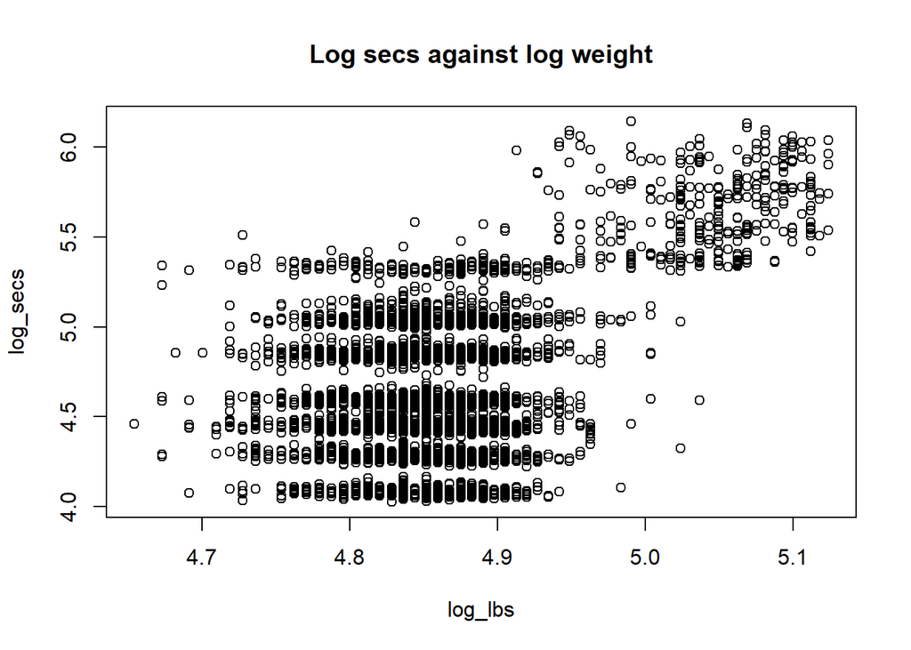

```r
plot(log_secs ~ log_lbs, data = df.horse_sample,
     main = "Log secs against log weight")
```

Would expect a positive correlation: the more weight a horse carries -> the longer it will take to complete the race. Somewhat visible.

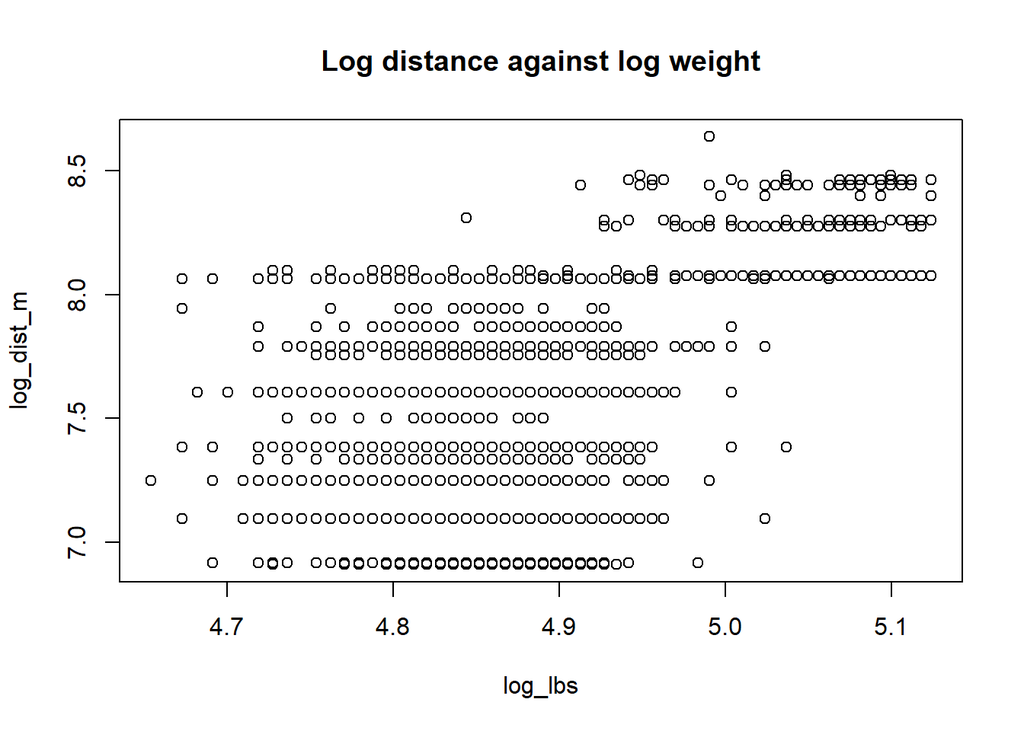

```r
plot(log_dist_m ~ log_lbs, data = df.horse_sample,
     main = "Log distance against log weight")
```

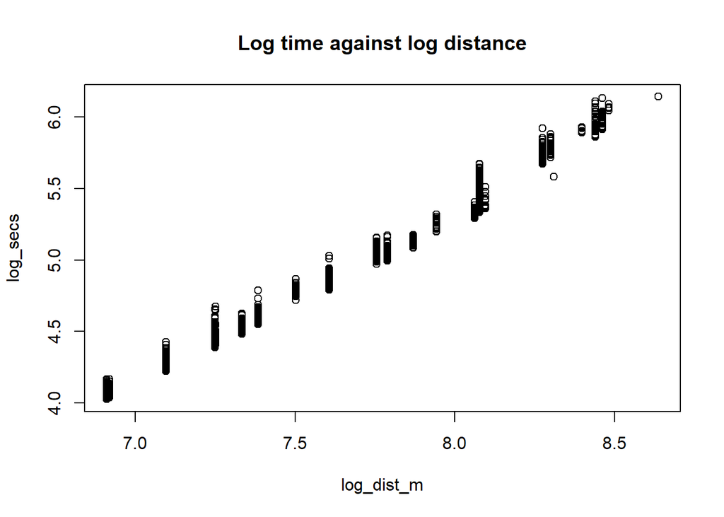

```r
plot(log_secs ~ log_dist_m, data = df.horse_sample,
     main = "Log time against log distance")
```

The longer the distance the longer time it takes. Logically sound and clearly visible.

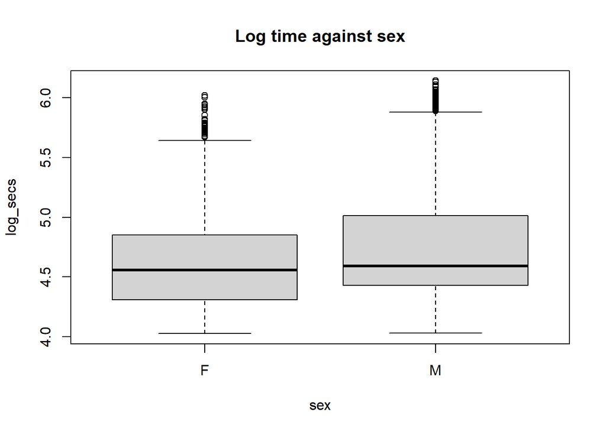

```r
plot(log_secs ~ sex, data = df.horse_sample,
     main = "Log time against sex")
```

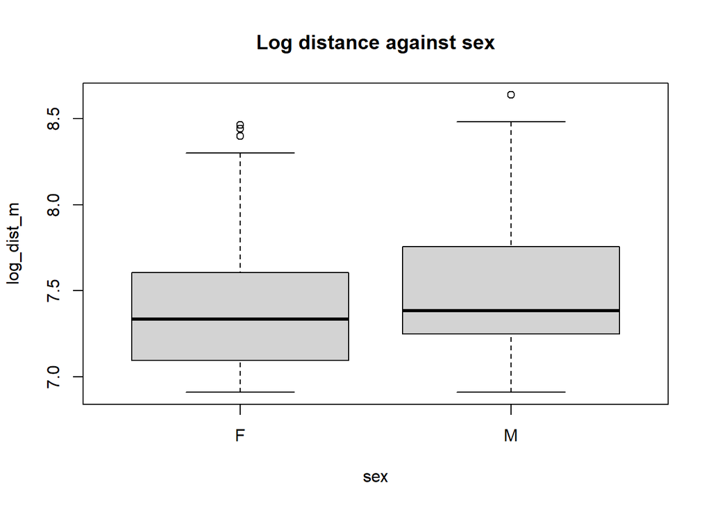

```r
plot(log_dist_m ~ sex, data = df.horse_sample,
     main = "Log distance against sex")
```

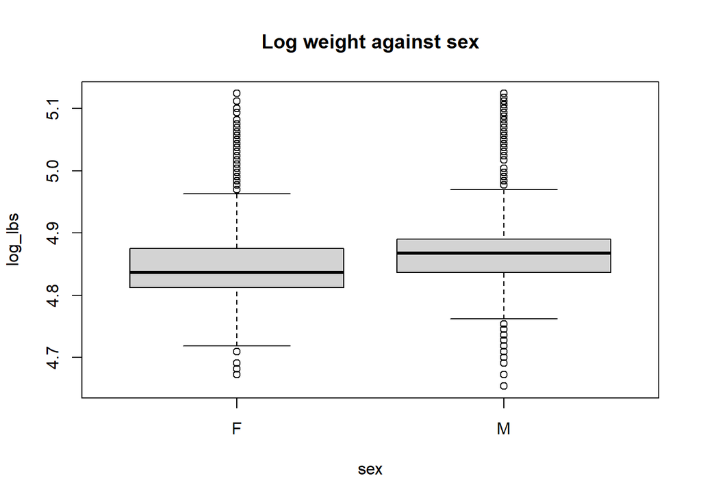

```r
plot(log_lbs ~ sex, data = df.horse_sample,
     main = "Log weight against sex")
```

THESE LAST 3 DON’T BELONG TO LINEAR MODELS! BUT LAB1 ALSO INCLUDES THESE…

Now let’s consider 2 predictors in a single graph.

[figure not shown]

```r
plot(log_dist_m ~ log_secs, data = df.horse_sample,
     col=sex,
     pch=19,
     main = "Log distance against log time")
legend("topleft",
       pch=19,
       legend=c("M","F"), # THESE ARE MANUALLY PROVIDED -> HOW CAN I KNOW WHICH IS WHICH???
       col=c("blue","red"))
```

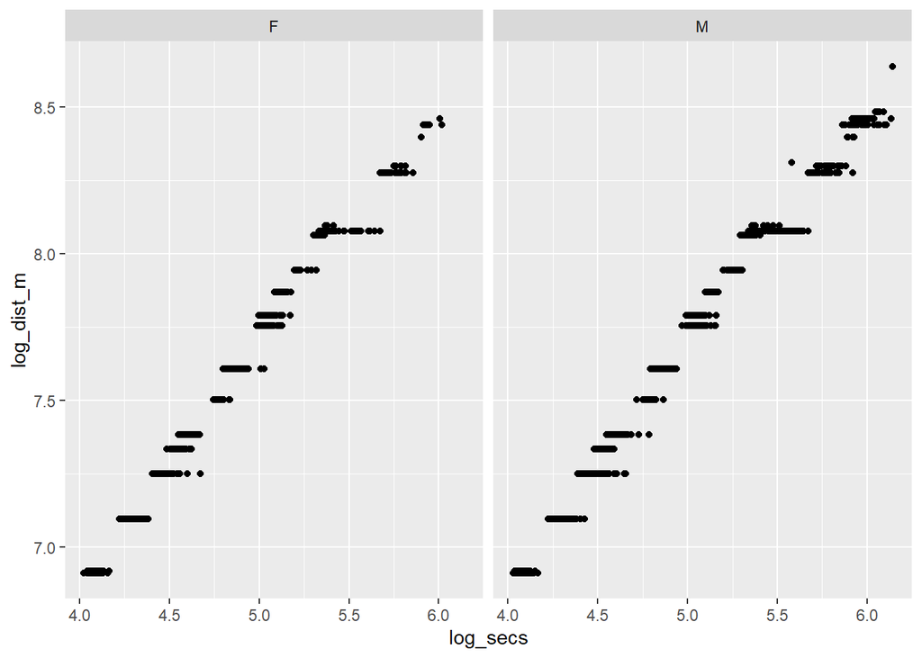

```r
library(ggplot2)
qplot(y= log_dist_m,x=log_secs,
data=df.horse_sample,
facets= ~sex)
```

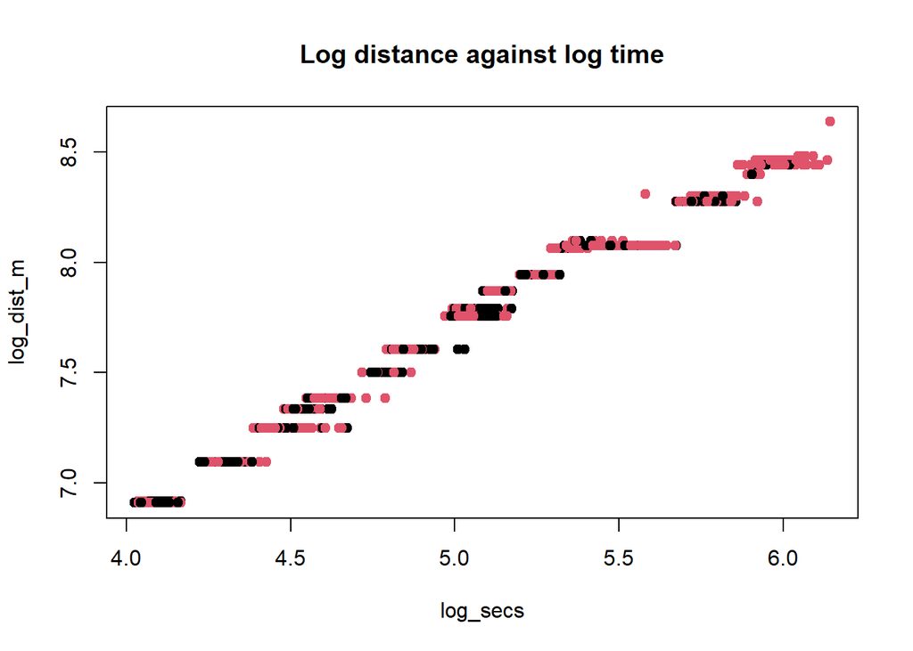

```r
plot(log_dist_m ~ log_secs, data = df.horse_sample,
     col=sex,
     pch=19,
     main = "Log distance against log time")
```

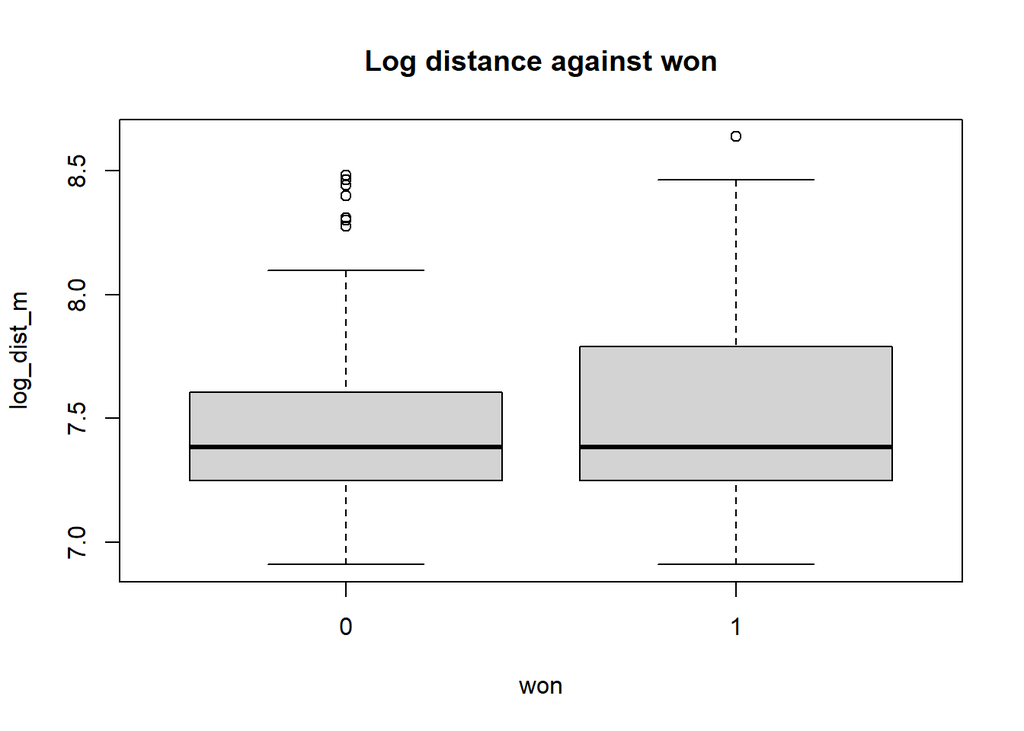

```r
boxplot(log_dist_m ~ won, data = df.horse_sample,
     main = "Log distance against won")
```

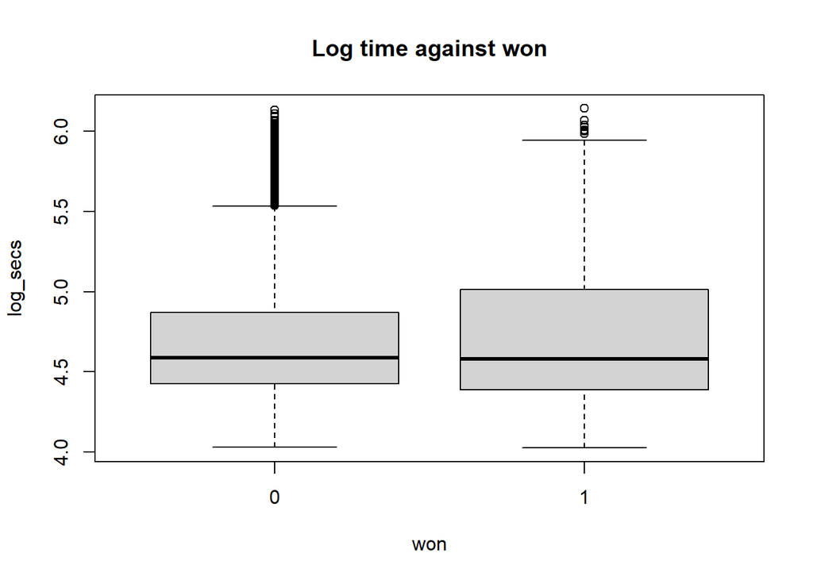

```r
boxplot(log_secs ~ won, data = df.horse_sample,
     main = "Log time against won")
```

Plotting against the “won” variable doesn’t really show anything.

NEXT STEP: fit models (see LinearModels1:CatsLab - 3 Fitting models)

# 3) Generalised Linear Model - Poisson

# 4) Generalised Linear Model - Binomial

## WIP

```r
glm.horse_sample <- glm(won ~ type + log_dist_m + going + age + sex + log_lbs + log_secs,
                data = df.horse_sample,
                family = "binomial")
summary(glm.horse_sample)
```

```
##
## Call:
## glm(formula = won ~ type + log_dist_m + going + age + sex + log_lbs +
##     log_secs, family = "binomial", data = df.horse_sample)
##
## Coefficients:
##                         Estimate Std. Error z value Pr(>|z|)
## (Intercept)           -143.53598    9.81531 -14.624  < 2e-16 ***
## typeFlat                -3.91240    0.62143  -6.296 3.06e-10 ***
## typeHurdle               0.03321    0.39908   0.083 0.933670
## typeNH Flat             -4.78548    0.77774  -6.153 7.60e-10 ***
## log_dist_m              38.32722    2.71295  14.128  < 2e-16 ***
## goingGood To Firm       -0.32848    0.28040  -1.171 0.241419
## goingGood To Soft        0.82178    0.34990   2.349 0.018843 *
## goingHeavy               3.58515    0.46646   7.686 1.52e-14 ***
## goingSoft                0.76116    0.42782   1.779 0.075212 .
## goingStandard           -0.09492    0.22260  -0.426 0.669808
## goingStandard To Slow   -0.18578    0.32119  -0.578 0.562991
## age                     -0.10293    0.02672  -3.853 0.000117 ***
## sexM                     0.01180    0.10097   0.117 0.906940
## log_lbs                  4.63524    1.06805   4.340 1.43e-05 ***
## log_secs               -34.76122    2.46491 -14.102  < 2e-16 ***
## ---
## Signif. codes:  0 '***' 0.001 '**' 0.01 '*' 0.05 '.' 0.1 ' ' 1
##
## (Dispersion parameter for binomial family taken to be 1)
##
##     Null deviance: 3784.7  on 5250  degrees of freedom
## Residual deviance: 3465.5  on 5236  degrees of freedom
## AIC: 3495.5
##
## Number of Fisher Scoring iterations: 5
```

HOW TO INTERPRET ALL THESE FACTOR VARIABLES? SHOULD THEY ALL BE FACTORS OR IS THERE A BETTER WAY? I DON’T REMEMBER SO MANY FACTORS FROM THE LECTURES.

# 5) Generalised Additive Model

# 6) Neural Network

# 7) Support Vector Machine

## WIP

Trying to find a good categorical target variable. Check the Distribution of sex_6:

```r
table(df.horse$sex_6)
```

```
##
##     C     F     G     H     M     R
##  5025 14751 28595   390  3753     3
```

The distribution of the sexes looks rather imbalanced. Since the rare categories (H, M, R) don’t have meaningful distinctions, combine them into an “Other” category:

```r
df.horse$sex_4 <- as.character(df.horse$sex_6)  # Convert to character to modify levels
df.horse$sex_4[df.horse$sex_4 %in% c("H", "M", "R")] <- "Other"  # Combine rare categories
df.horse$sex_4 <- as.factor(df.horse$sex_4)  # Convert back to factor

# Check the new distribution
table(df.horse$sex_4)
```

```
##
##     C     F     G Other
##  5025 14751 28595  4146
```

#TODO: #CONTINUE WITH THIS: Stratified Sampling for Training Ensure that training data is representative by using stratified sampling. This prevents the model from being biased toward majority classes during training:

```r
library(caret)
## Stratified train-test split
trainIndex <- createDataPartition(df.horse$sex_4, p = 0.7, list = FALSE)
df_train <- df.horse[trainIndex, ]
df_test <- df.horse[-trainIndex, ]
```

# 8) Use of Generative AI

# 9) Conclusion

## WIP

- Conclusions were a lot less clear to draw from this real-world dataset than in the case of the sample datasets presented at the lectures.